# Task2 Merge

Yaru

2022-08-13

```r
# load two raw datasets "icu_patients_df1" and "icu_patients_df0"
icu_patients_df0 <- readRDS("icu_patients_df0.rds")
icu_patients_df1 <- readRDS("icu_patients_df1.rds")

# data preparation for "icu_patients_df1"
head(icu_patients_df1) # check the basic information of "icu_patients_df1"
```

```
##   RecordID Length_of_stay SAPS1 SOFA Survival in_hospital_death Days Status Age
## 1   132539              5     6    1       NA                 0 2408  FALSE  54
## 2   132540              8    16    8       NA                 0 2408  FALSE  76
## 3   132541             19    21   11       NA                 0 2408  FALSE  44
## 4   132543              9     7    1      575                 0  575   TRUE  68
## 5   132545              4    17    2      918                 0  918   TRUE  88
## 6   132547              6    14   11     1637                 0 1637   TRUE  64
##   Albumin_diff Albumin_max Albumin_min   ALP_diff ALP_max ALP_min  ALT_diff
## 1    0.2186633         3.2         3.1 118.147964     214     202  80.44617
## 2    0.8813367         2.1         2.2 252.147964     338     348  94.44617
## 3    0.6813367         2.7         2.3  31.147964     127     105  45.44617
## 4    1.4186633         4.4         4.4   9.147964     105     105 108.44617
## 5    0.3813367         2.7         2.6  56.852036      39      78  96.44617
## 6    0.4186633         3.4         3.3   5.147964     101     101  75.44617
##   ALT_max ALT_min  AST_diff AST_max AST_min Bilirubin_diff Bilirubin_max
```

[output cut: 111 more lines]

```r
nrow(icu_patients_df1)
```

```
## [1] 2061
```

```r
ncol(icu_patients_df1)
```

```
## [1] 120
```

```r
sum(is.na(icu_patients_df1))
```

```
## [1] 11193
```

```r
icu_removed_na <- icu_patients_df1[colSums(is.na(icu_patients_df1))/nrow(icu_patients_df1) < .2]
icu_removed_na <- na.omit(icu_removed_na)
icu_removed_na$SOFA[icu_removed_na$SOFA == -1] <- NA
icu_removed_na$Length_of_stay[icu_removed_na$Length_of_stay == -1] <- NA
icu_removed_na <- na.omit(icu_removed_na) # data cleaning
nrow(icu_removed_na)
```

```
## [1] 1819
```

```r
ncol(icu_removed_na)
```

```
## [1] 103
```

```r
sum(is.na(icu_removed_na)) # check the basic information of "icu_removed_na"
```

```
## [1] 0
```

```r
# data preparation for "icu_patients_df0"
icu_final <- icu_patients_df0[colSums(is.na(icu_patients_df0))/nrow(icu_patients_df0) < .2]
icu_final <- na.omit(icu_final)
icu_final$SOFA[icu_final$SOFA == -1] <- NA
icu_final$Length_of_stay[icu_final$Length_of_stay == -1] <- NA
icu_final$Weight_diff[icu_final$Weight_diff == Inf] <- NA
icu_final$Weight_max[icu_final$Weight_max == -Inf] <- NA
icu_final$Weight_min[icu_final$Weight_min == Inf] <- NA
icu_final$Height[icu_final$Height == -Inf] <- NA
icu_final <- na.omit(icu_final)
nrow(icu_final)
```

```
## [1] 873
```

```r
ncol(icu_final)
```

```
## [1] 56
```

```r
sum(is.na(icu_final)) # check the basic information of "icu_final" (use for survival analysis)
```

```
## [1] 0
```

# Task 2

In this task, you are required to develop a Cox proportional hazards survival model using the `icu_patients_df1` data set which adequately explains or predicts the length of survival indicated by the `Days` variable, with censoring as indicated by the `Status` variable. You should fit a series of models, maybe three or four, evaluating each one, before you present your final model. Your final model should **not** include all the predictor variables, just a small subset of them, which you have selected based on statistical significance and/or background knowledge. Aim for between five and ten predictor variables (slightly more or fewer is OK). It is perfectly acceptable to include predictor variables in your final model which are not statistically significant, as long as you justify their inclusion on medical or physiological grounds (you will not be marked down if your medical justification is not exactly correct, but do you best). You should assess each model you consider for goodness of fit and other relevant statistics, and you should assess your final model for violations of assumptions and perform other diagnostics which you think are relevant (and modify the model if indicated, or at least comment on the possible impact of what your diagnostics show). Finally, re-fit your final model to the unimputed data frame (`icu_patients_df0.rds`) and comment on any differences you find.

### Hints

1. Select an initial subset of explanatory variables that you will use to predict survival. Justify your choice.
2. Conduct basic exploratory data analysis on your variables of choice.
3. Fit appropriate univariate Cox proportional hazards models.
4. Fit an appropriate series of multivariable Cox proportional hazards models, justifying your approach. Assess each model you consider for goodness of fit and other relevant statistics.
5. Present your final model. Your final model should **not** include all the predictor variables, just a small subset of them, which you have selected based on statistical significance and/or background knowledge.
6. For your final model, present a set of diagnostic statistics and/or charts and comment on them.
7. Write a paragraph or two summarising the most important findings of your final model. Include the most important values from the statistical output, and a simple clinical interpretation.

**Create your response to this task here, as a mixture of embedded (`knitr`) R code and any resulting outputs, and explanatory or commentary text.**

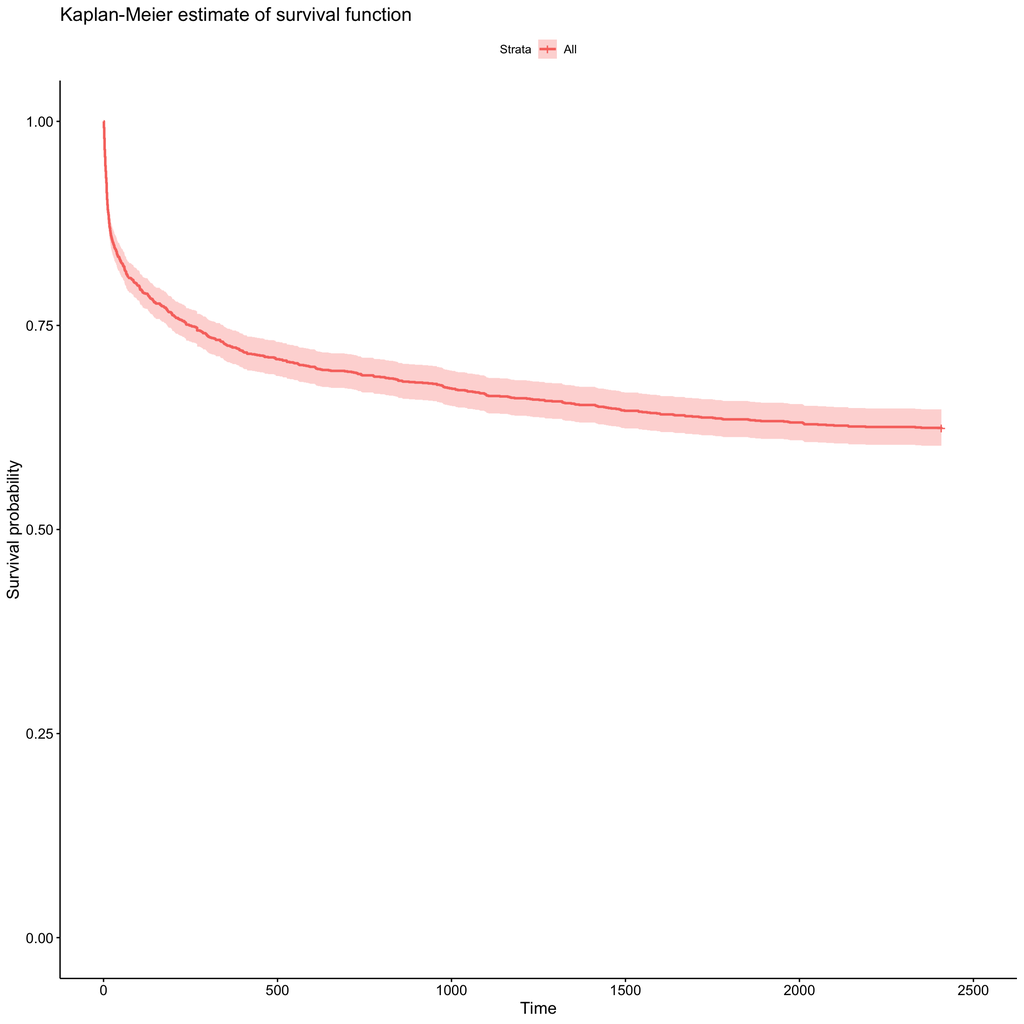

```r
# overall Kaplan-Meier estimate and Nelson-Aalen estimate for "icu_removed_na"
om.fit <- survfit( Surv(Days, Status) ~ 1, data = icu_removed_na)
ggsurvplot(om.fit, title = 'Kaplan-Meier estimate of survival function')
```

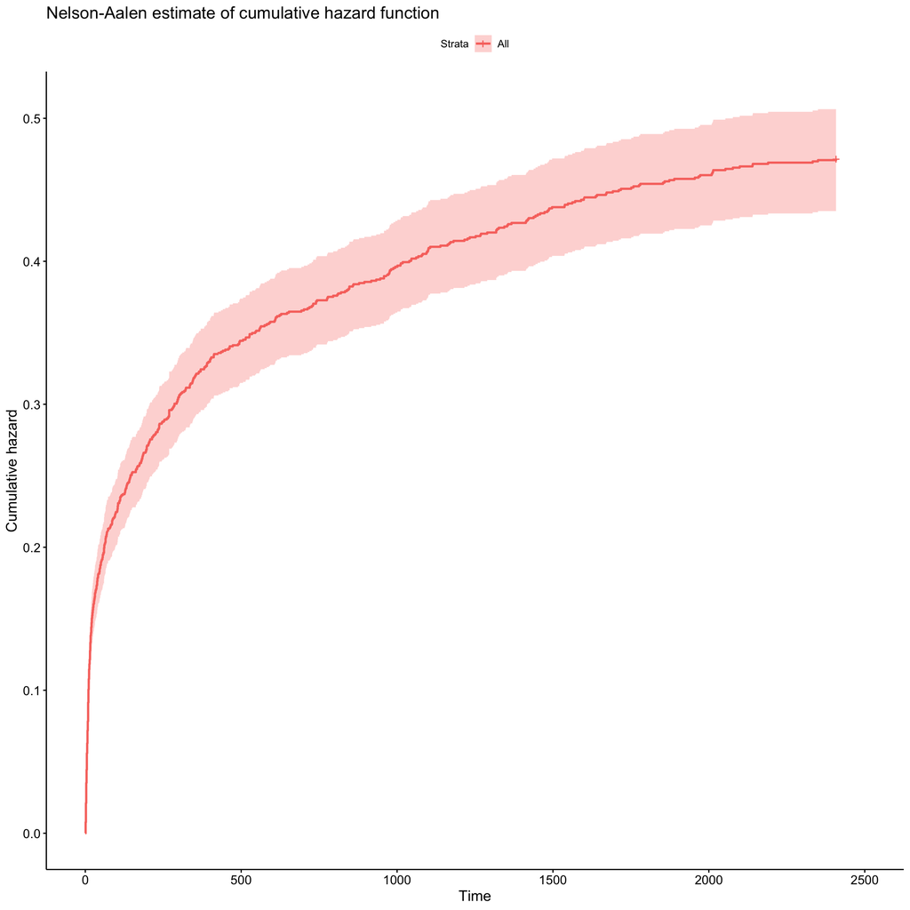

```r
ggsurvplot(om.fit, fun="cumhaz", title = "Nelson-Aalen estimate of cumulative hazard function")
```

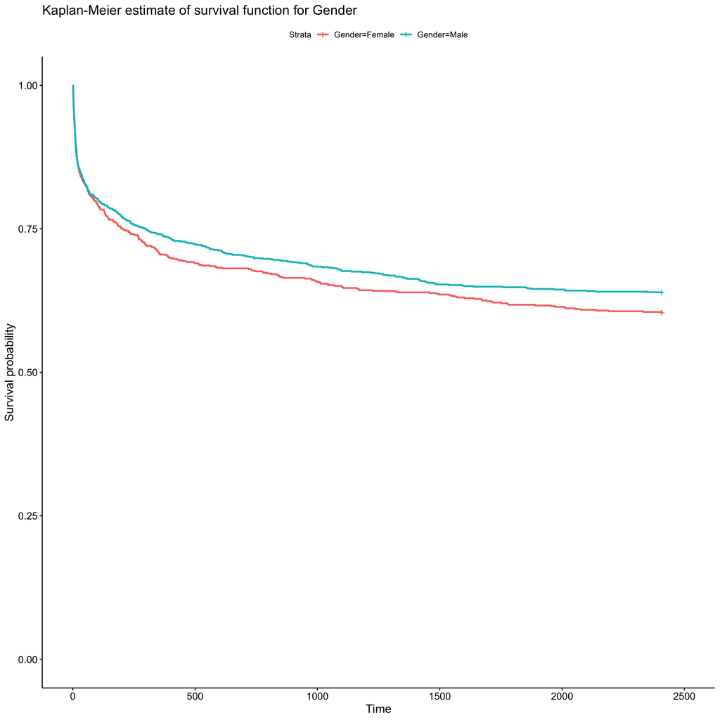

```r
# choose "gender" variable and comparing survival functions between male and female
om.fitbygender <- survfit( Surv(Days, Status) ~ Gender, data = icu_removed_na)
ggsurvplot(om.fitbygender, title= 'Kaplan-Meier estimate of survival function for Gender')
```

```r
# Carry out the log-rank tests for differences in survival experience by gender
om.fitbygender2 <- coxph( Surv(Days, Status) ~ Gender, data = icu_removed_na)
summary(om.fitbygender2)
```

```
## Call:
## coxph(formula = Surv(Days, Status) ~ Gender, data = icu_removed_na)
##
##   n= 1819, number of events= 684
##
##                coef exp(coef) se(coef)      z Pr(>|z|)
## GenderMale -0.11099   0.89495  0.07675 -1.446    0.148
##
##            exp(coef) exp(-coef) lower .95 upper .95
## GenderMale    0.8949      1.117      0.77      1.04
##
## Concordance= 0.513  (se = 0.01 )
## Likelihood ratio test= 2.08  on 1 df,   p=0.1
## Wald test            = 2.09  on 1 df,   p=0.1
## Score (logrank) test = 2.09  on 1 df,   p=0.1
```

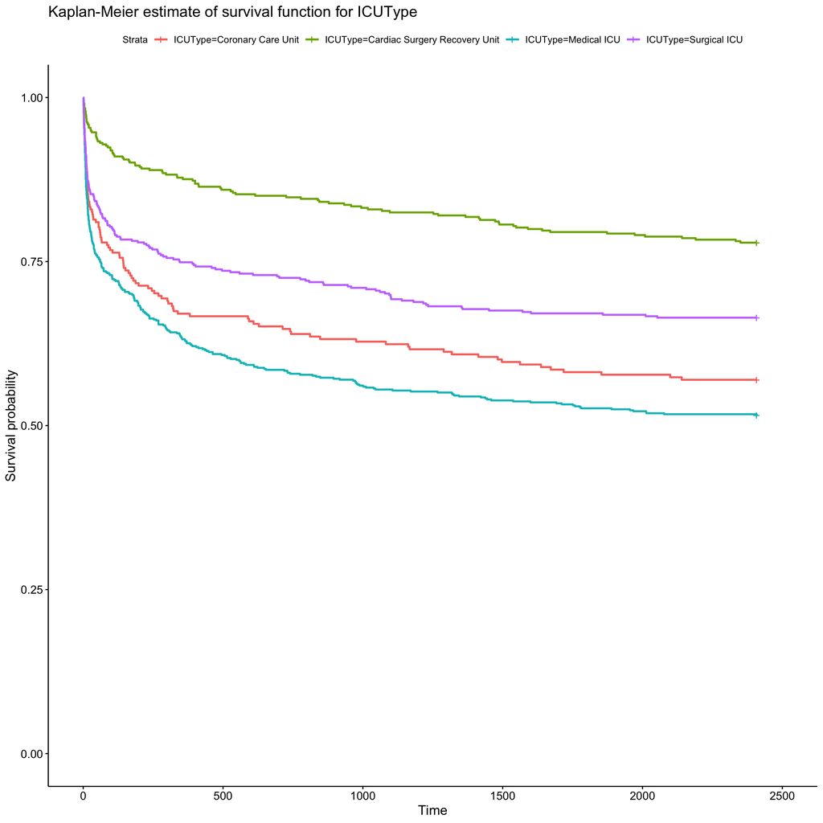

```r
# choose "ICUType" variable and comparing survival functions between male and female
om.fitbyicutype <- survfit( Surv(Days, Status) ~ ICUType, data = icu_removed_na)
ggsurvplot(om.fitbyicutype, title= 'Kaplan-Meier estimate of survival function for ICUType')
```

```r
# carry out the log-rank tests for differences in survival experience by icutype
om.fitbyicutype4 <- coxph( Surv(Days, Status) ~ ICUType, data = icu_removed_na)
summary(om.fitbyicutype4)
```

```
## Call:
## coxph(formula = Surv(Days, Status) ~ ICUType, data = icu_removed_na)
##
##   n= 1819, number of events= 684
##
##                                         coef exp(coef) se(coef)      z Pr(>|z|)
## ICUTypeCardiac Surgery Recovery Unit -0.8362    0.4333   0.1394 -5.998    2e-09
## ICUTypeMedical ICU                    0.1711    1.1866   0.1101  1.554   0.1202
## ICUTypeSurgical ICU                  -0.3051    0.7371   0.1244 -2.453   0.0142
##
## ICUTypeCardiac Surgery Recovery Unit ***
## ICUTypeMedical ICU
## ICUTypeSurgical ICU                  *
## ---
## Signif. codes:  0 '***' 0.001 '**' 0.01 '*' 0.05 '.' 0.1 ' ' 1
##
##                                      exp(coef) exp(-coef) lower .95 upper .95
## ICUTypeCardiac Surgery Recovery Unit    0.4333     2.3076    0.3297    0.5695
## ICUTypeMedical ICU                      1.1866     0.8428    0.9563    1.4723
## ICUTypeSurgical ICU                     0.7371     1.3567    0.5776    0.9405
##
## Concordance= 0.602  (se = 0.01 )
## Likelihood ratio test= 93.17  on 3 df,   p=<2e-16
## Wald test            = 83.12  on 3 df,   p=<2e-16
## Score (logrank) test = 88.22  on 3 df,   p=<2e-16
```

*From above we can find that the variable ‘Gender’ is not significant, the variable ‘ICUType’ is strongly significant just on the level ‘ICUTypeCardiac Surgery Recovery Unit’ and slightly significant on the level ‘ICUTypeSurgical ICU’.*

```r
# fitting the univariate Cox proportional hazards models for "icu_removed_na"
covariates <- c("Length_of_stay", "SAPS1", "SOFA", "Age", "Albumin_diff", "Albumin_max", "Albumin_min", "ALP_diff", "ALP_max", "ALP_min", "ALT_diff",
"ALT_max", "ALT_min", "AST_diff", "AST_max", "AST_min", "Bilirubin_diff", "Bilirubin_max", "Bilirubin_min", "BUN_diff", "BUN_max", "BUN_min", "Cholesterol_diff", "Cholesterol_max", "Cholesterol_min", "Creatinine_diff", "Creatinine_max", "Creatinine_min", "FiO2_diff", "FiO2_max", "FiO2_min", "GCS_diff", "GCS_max", "GCS_min", "Gender", "Glucose_diff", "Glucose_max", "Glucose_min", "HCO3_diff", "HCO3_max", "HCO3_min", "HCT_diff", "HCT_max", "HCT_min", "HR_diff", "HR_max", "HR_min", "ICUType", "K_diff", "K_max", "K_min", "Lactate_diff", "Lactate_max", "Lactate_min", "MAP_diff", "MAP_max", "MAP_min", "Mg_diff", "Mg_max", "Mg_min", "Na_diff", "Na_max", "Na_min", "PaCO2_diff", "PaCO2_max", "PaCO2_min",
"PaO2_diff", "PaO2_max", "PaO2_min", "pH_diff", "pH_max", "pH_min", "Platelets_diff", "Platelets_max", "Platelets_min", "RespRate_diff", "RespRate_max", "RespRate_min", "SaO2_diff", "SaO2_max", "SaO2_min", "Temp_diff", "Temp_max", "Temp_min", "TroponinI_diff", "TroponinI_max", "TroponinI_min", "TroponinT_diff", "TroponinT_max", "TroponinT_min", "Urine_diff", "Urine_max", "Urine_min", "WBC_diff", "WBC_max", "WBC_min", "Weight_diff", "Weight_max","Weight_min")

univ_formulas <- sapply(covariates,
                        function(x) as.formula(paste('Surv(Days, Status)~', x)))

univ_models <- lapply( univ_formulas, function(x){coxph(x, data = icu_removed_na)})
univ_results <- lapply(univ_models,
                       function(x){
                          x <- summary(x)
                          p.value<-signif(x$wald["pvalue"], digits=2)
                          wald.test<-signif(x$wald["test"], digits=2)
                          beta<-signif(x$coef[1], digits=2);#coeficient beta
                          HR <-signif(x$coef[2], digits=2);#exp(beta)
                          HR.confint.lower <- signif(x$conf.int[,"lower .95"], 2)
                          HR.confint.upper <- signif(x$conf.int[,"upper .95"],2)
                          HR <- paste0(HR, " (",
                                       HR.confint.lower, "-", HR.confint.upper, ")")
                          res<-c(beta, HR, wald.test, p.value)
                          names(res)<-c("beta", "HR (95% CI for HR)", "wald.test",
                                        "p.value")
                          return(res)
                          return(exp(cbind(coef(x),confint(x))))
                         })
print(univ_results) # extract data
```

```
## $Length_of_stay
##               beta HR (95% CI for HR)          wald.test            p.value
##             "0.01"          "1 (1-1)"               "19"          "1.1e-05"
##
## $SAPS1
##               beta HR (95% CI for HR)          wald.test            p.value
##             "0.07"    "1.1 (1.1-1.1)"               "85"          "3.7e-20"
##
## $SOFA
##               beta HR (95% CI for HR)          wald.test            p.value
##            "0.065"      "1.1 (1-1.1)"               "43"          "4.3e-11"
##
## $Age
##               beta HR (95% CI for HR)          wald.test            p.value
##            "0.034"          "1 (1-1)"              "160"          "1.6e-36"
##
## $Albumin_diff
##               beta HR (95% CI for HR)          wald.test            p.value
##            "-0.09"  "0.91 (0.75-1.1)"             "0.78"             "0.38"
##
## $Albumin_max
##               beta HR (95% CI for HR)          wald.test            p.value
##            "-0.18" "0.84 (0.74-0.94)"              "8.7"           "0.0031"
##
## $Albumin_min
##               beta HR (95% CI for HR)          wald.test            p.value
##             "-0.2" "0.82 (0.73-0.92)"               "11"          "0.00094"
##
## $ALP_diff
##               beta HR (95% CI for HR)          wald.test            p.value
##          "0.00094"          "1 (1-1)"                "4"            "0.047"
##
## $ALP_max
##               beta HR (95% CI for HR)          wald.test            p.value
##           "0.0012"          "1 (1-1)"               "11"          "0.00088"
##
## $ALP_min
##               beta HR (95% CI for HR)          wald.test            p.value
##           "0.0014"          "1 (1-1)"               "12"          "0.00062"
##
```

[output cut: 342 more lines]

```
## $WBC_min
##               beta HR (95% CI for HR)          wald.test            p.value
##           "0.0068"          "1 (1-1)"              "1.6"              "0.2"
##
## $Weight_diff
##               beta HR (95% CI for HR)          wald.test            p.value
##           "0.0043"          "1 (1-1)"              "3.9"            "0.048"
##
## $Weight_max
##               beta HR (95% CI for HR)          wald.test            p.value
##          "-0.0083"    "0.99 (0.99-1)"               "21"          "5.2e-06"
##
## $Weight_min
##               beta HR (95% CI for HR)          wald.test            p.value
##          "-0.0071"    "0.99 (0.99-1)"               "15"          "0.00011"
```

*From above we pick variables with p-value <0.005 to fit our first multivariable Cox model.*

```r
# pick variables with p-value <0.005 from the univariate Cox model as model 1
cox.mv1 <- coxph( Surv(Days, Status) ~ Length_of_stay + SAPS1 + SOFA + Age + Albumin_max + Albumin_min + ALP_max + ALP_min + AST_diff + AST_max + AST_min + Bilirubin_diff + Bilirubin_max + Bilirubin_min + BUN_diff + BUN_max + BUN_min + Cholesterol_max + Creatinine_diff + Creatinine_max + Creatinine_min + FiO2_diff + FiO2_max + GCS_diff + GCS_max + Glucose_diff + Glucose_max + HCO3_diff + HCT_diff + HCT_max + HR_diff + Lactate_diff + Lactate_max + Lactate_min + Na_diff + PaCO2_diff + PaO2_diff + PaO2_max + pH_diff + pH_min + RespRate_max + RespRate_min + Temp_max + Urine_diff + Urine_max + Urine_min + WBC_diff + Weight_max + Weight_min, data = icu_removed_na)
summary(cox.mv1)
```

```
## Call:
## coxph(formula = Surv(Days, Status) ~ Length_of_stay + SAPS1 +
##     SOFA + Age + Albumin_max + Albumin_min + ALP_max + ALP_min +
##     AST_diff + AST_max + AST_min + Bilirubin_diff + Bilirubin_max +
##     Bilirubin_min + BUN_diff + BUN_max + BUN_min + Cholesterol_max +
##     Creatinine_diff + Creatinine_max + Creatinine_min + FiO2_diff +
##     FiO2_max + GCS_diff + GCS_max + Glucose_diff + Glucose_max +
##     HCO3_diff + HCT_diff + HCT_max + HR_diff + Lactate_diff +
##     Lactate_max + Lactate_min + Na_diff + PaCO2_diff + PaO2_diff +
##     PaO2_max + pH_diff + pH_min + RespRate_max + RespRate_min +
##     Temp_max + Urine_diff + Urine_max + Urine_min + WBC_diff +
##     Weight_max + Weight_min, data = icu_removed_na)
##
##   n= 1819, number of events= 684
##
##                       coef  exp(coef)   se(coef)      z Pr(>|z|)
## Length_of_stay   4.111e-03  1.004e+00  2.917e-03  1.410 0.158633
## SAPS1            4.554e-02  1.047e+00  1.388e-02  3.281 0.001036 **
## SOFA             6.176e-03  1.006e+00  1.715e-02  0.360 0.718743
## Age              2.628e-02  1.027e+00  3.365e-03  7.809 5.76e-15 ***
## Albumin_max      2.410e-01  1.273e+00  2.356e-01  1.023 0.306316
## Albumin_min     -2.273e-01  7.967e-01  2.305e-01 -0.986 0.324041
## ALP_max         -1.241e-03  9.988e-01  2.030e-03 -0.611 0.540903
## ALP_min          2.242e-03  1.002e+00  2.184e-03  1.027 0.304572
## AST_diff         2.823e-05  1.000e+00  4.074e-04  0.069 0.944751
## AST_max          1.559e-04  1.000e+00  4.069e-04  0.383 0.701712
## AST_min         -1.441e-04  9.999e-01  1.909e-04 -0.755 0.450483
## Bilirubin_diff  -1.026e-01  9.025e-01  4.854e-02 -2.114 0.034540 *
## Bilirubin_max   -7.079e-03  9.929e-01  5.732e-02 -0.124 0.901700
## Bilirubin_min    1.239e-01  1.132e+00  5.347e-02  2.318 0.020476 *
## BUN_diff        -1.978e-03  9.980e-01  5.476e-03 -0.361 0.717982
## BUN_max         -4.706e-03  9.953e-01  1.019e-02 -0.462 0.644086
## BUN_min          2.073e-02  1.021e+00  9.498e-03  2.183 0.029060 *
## Cholesterol_max -3.118e-04  9.997e-01  1.401e-03 -0.223 0.823873
## Creatinine_diff  5.153e-02  1.053e+00  1.132e-01  0.455 0.648963
## Creatinine_max  -2.413e-01  7.856e-01  1.933e-01 -1.248 0.211880
## Creatinine_min   1.434e-01  1.154e+00  1.764e-01  0.813 0.416389
## FiO2_diff       -2.890e-01  7.490e-01  5.966e-01 -0.484 0.628072
## FiO2_max        -1.448e-02  9.856e-01  3.948e-01 -0.037 0.970734
## GCS_diff        -4.376e-02  9.572e-01  2.387e-02 -1.833 0.066789 .
```

[output cut: 68 more lines]

```
## pH_min             1.5056     0.6642    0.4612    4.9152
## RespRate_max       0.9988     1.0012    0.9859    1.0118
## RespRate_min       0.9824     1.0180    0.9501    1.0157
## Temp_max           0.9066     1.1030    0.8134    1.0105
## Urine_diff         1.0011     0.9989    0.9989    1.0032
## Urine_max          0.9988     1.0012    0.9967    1.0009
## Urine_min          0.9993     1.0007    0.9973    1.0012
## WBC_diff           1.0039     0.9962    0.9940    1.0138
## Weight_max         0.9788     1.0217    0.9579    1.0002
## Weight_min         1.0185     0.9818    0.9966    1.0409
##
## Concordance= 0.75  (se = 0.009 )
## Likelihood ratio test= 547.8  on 49 df,   p=<2e-16
## Wald test            = 558.7  on 49 df,   p=<2e-16
## Score (logrank) test = 631  on 49 df,   p=<2e-16
```

```r
print(drop1(cox.mv1, test="Chisq"))
```

```
## Single term deletions
##
## Model:
## Surv(Days, Status) ~ Length_of_stay + SAPS1 + SOFA + Age + Albumin_max +
##     Albumin_min + ALP_max + ALP_min + AST_diff + AST_max + AST_min +
##     Bilirubin_diff + Bilirubin_max + Bilirubin_min + BUN_diff +
##     BUN_max + BUN_min + Cholesterol_max + Creatinine_diff + Creatinine_max +
##     Creatinine_min + FiO2_diff + FiO2_max + GCS_diff + GCS_max +
##     Glucose_diff + Glucose_max + HCO3_diff + HCT_diff + HCT_max +
##     HR_diff + Lactate_diff + Lactate_max + Lactate_min + Na_diff +
##     PaCO2_diff + PaO2_diff + PaO2_max + pH_diff + pH_min + RespRate_max +
##     RespRate_min + Temp_max + Urine_diff + Urine_max + Urine_min +
##     WBC_diff + Weight_max + Weight_min
##                 Df    AIC    LRT  Pr(>Chi)
## <none>             9521.6
## Length_of_stay   1 9521.5  1.890 0.1692295
## SAPS1            1 9530.3 10.742 0.0010474 **
## SOFA             1 9519.7  0.130 0.7187606
## Age              1 9584.8 65.211 6.729e-16 ***
## Albumin_max      1 9520.6  1.033 0.3093751
## Albumin_min      1 9520.6  0.960 0.3271084
## ALP_max          1 9520.0  0.385 0.5349196
## ALP_min          1 9520.7  1.095 0.2953720
## AST_diff         1 9519.6  0.005 0.9447572
## AST_max          1 9519.7  0.147 0.7014040
## AST_min          1 9520.2  0.574 0.4487429
## Bilirubin_diff   1 9524.0  4.396 0.0360152 *
## Bilirubin_max    1 9519.6  0.015 0.9016412
## Bilirubin_min    1 9525.3  5.659 0.0173672 *
## BUN_diff         1 9519.7  0.131 0.7178610
## BUN_max          1 9519.8  0.215 0.6425641
## BUN_min          1 9524.6  5.047 0.0246699 *
## Cholesterol_max  1 9519.7  0.050 0.8238760
## Creatinine_diff  1 9519.8  0.206 0.6495658
## Creatinine_max   1 9521.2  1.621 0.2028900
## Creatinine_min   1 9520.3  0.693 0.4050720
## FiO2_diff        1 9519.8  0.235 0.6276817
## FiO2_max         1 9519.6  0.001 0.9707423
## GCS_diff         1 9522.9  3.328 0.0681290 .
## GCS_max          1 9549.2 29.614 5.272e-08 ***
```

[output cut: 11 more lines]

```
## PaO2_diff        1 9520.3  0.708 0.4002613
## PaO2_max         1 9532.1 12.521 0.0004024 ***
## pH_diff          1 9521.4  1.775 0.1827914
## pH_min           1 9520.1  0.456 0.4997317
## RespRate_max     1 9519.6  0.034 0.8529286
## RespRate_min     1 9520.7  1.090 0.2965251
## Temp_max         1 9522.8  3.177 0.0746756 .
## Urine_diff       1 9520.5  0.933 0.3341627
## Urine_max        1 9520.9  1.258 0.2620450
## Urine_min        1 9520.1  0.546 0.4600856
## WBC_diff         1 9520.1  0.536 0.4642363
## Weight_max       1 9524.6  4.983 0.0255904 *
## Weight_min       1 9523.0  3.396 0.0653468 .
## ---
## Signif. codes:  0 '***' 0.001 '**' 0.01 '*' 0.05 '.' 0.1 ' ' 1
```

```r
# pick variables that are significant based on the previous' cox.mv1 likelihood ratio test as model 11
cox.mv11 <- coxph(Surv(Days, Status) ~ SAPS1 + Age + Bilirubin_diff + Bilirubin_min + BUN_min + GCS_max + HCT_diff + Lactate_diff + PaO2_max + Weight_max, data = icu_removed_na)
summary(cox.mv11)
```

```
## Call:
## coxph(formula = Surv(Days, Status) ~ SAPS1 + Age + Bilirubin_diff +
##     Bilirubin_min + BUN_min + GCS_max + HCT_diff + Lactate_diff +
##     PaO2_max + Weight_max, data = icu_removed_na)
##
##   n= 1819, number of events= 684
##
##                      coef  exp(coef)   se(coef)      z Pr(>|z|)
## SAPS1           0.0415478  1.0424230  0.0094215  4.410 1.03e-05 ***
## Age             0.0276923  1.0280793  0.0028960  9.562  < 2e-16 ***
## Bilirubin_diff -0.0986596  0.9060511  0.0393899 -2.505  0.01226 *
## Bilirubin_min   0.1168183  1.1239151  0.0381036  3.066  0.00217 **
## BUN_min         0.0151890  1.0153049  0.0016090  9.440  < 2e-16 ***
## GCS_max        -0.0860330  0.9175640  0.0130078 -6.614 3.74e-11 ***
## HCT_diff       -0.0338016  0.9667633  0.0113834 -2.969  0.00298 **
## Lactate_diff    0.1156444  1.1225966  0.0210669  5.489 4.03e-08 ***
## PaO2_max       -0.0025664  0.9974369  0.0003801 -6.751 1.47e-11 ***
## Weight_max     -0.0056588  0.9943572  0.0019084 -2.965  0.00302 **
## ---
## Signif. codes:  0 '***' 0.001 '**' 0.01 '*' 0.05 '.' 0.1 ' ' 1
##
##                exp(coef) exp(-coef) lower .95 upper .95
## SAPS1             1.0424     0.9593    1.0234    1.0619
## Age               1.0281     0.9727    1.0223    1.0339
## Bilirubin_diff    0.9061     1.1037    0.8387    0.9788
## Bilirubin_min     1.1239     0.8897    1.0430    1.2111
## BUN_min           1.0153     0.9849    1.0121    1.0185
## GCS_max           0.9176     1.0898    0.8945    0.9413
## HCT_diff          0.9668     1.0344    0.9454    0.9886
## Lactate_diff      1.1226     0.8908    1.0772    1.1699
## PaO2_max          0.9974     1.0026    0.9967    0.9982
## Weight_max        0.9944     1.0057    0.9906    0.9981
##
## Concordance= 0.732  (se = 0.009 )
## Likelihood ratio test= 472.6  on 10 df,   p=<2e-16
## Wald test            = 478.3  on 10 df,   p=<2e-16
## Score (logrank) test = 501.8  on 10 df,   p=<2e-16
```

```r
# fit a multivariable Cox model with all variables as model 2
cox.mv2 <- coxph(Surv(Days, Status) ~ Gender + Length_of_stay + SAPS1 + SOFA + Age + ICUType + Urine_diff + Lactate_diff + HR_diff + Bilirubin_diff + Albumin_diff + Albumin_max + Albumin_min + ALP_max + ALP_min + ALT_max + ALT_min + AST_max + AST_min + Bilirubin_max + Bilirubin_min + BUN_max + BUN_min + Cholesterol_max + Cholesterol_min + Creatinine_max + Creatinine_min + FiO2_max + FiO2_min + GCS_max + GCS_min + Glucose_max + Glucose_min + HCO3_max + HCO3_min + HCT_max + HCT_min + HR_max + HR_min + K_max + K_min + Lactate_max + Lactate_min + MAP_max + MAP_min +  Mg_max + Mg_min + Na_max + Na_min + PaCO2_max + PaCO2_min + PaO2_max + PaO2_min + pH_max + pH_min + Platelets_max + Platelets_min + RespRate_max + RespRate_min + SaO2_max + SaO2_min + Temp_max + Temp_min + TroponinI_max + TroponinI_min + TroponinT_max + TroponinT_min + Urine_max + Urine_min + WBC_max + WBC_min + Weight_max + Weight_min + Albumin_diff + ALP_diff + ALT_diff + AST_diff  + Bilirubin_diff + BUN_diff + Cholesterol_diff + Creatinine_diff + FiO2_diff + GCS_diff + Glucose_diff + HCO3_diff + HCT_diff + HR_diff + K_diff + Lactate_diff + MAP_diff + Mg_diff + Na_diff + PaCO2_diff + PaO2_diff+  Platelets_diff + pH_diff + RespRate_diff + SaO2_diff + Temp_diff + TroponinI_diff + TroponinT_diff + Urine_diff + WBC_diff + Weight_diff, data = icu_removed_na)
summary(cox.mv2)
```

```
## Call:
## coxph(formula = Surv(Days, Status) ~ Gender + Length_of_stay +
##     SAPS1 + SOFA + Age + ICUType + Urine_diff + Lactate_diff +
##     HR_diff + Bilirubin_diff + Albumin_diff + Albumin_max + Albumin_min +
##     ALP_max + ALP_min + ALT_max + ALT_min + AST_max + AST_min +
##     Bilirubin_max + Bilirubin_min + BUN_max + BUN_min + Cholesterol_max +
##     Cholesterol_min + Creatinine_max + Creatinine_min + FiO2_max +
##     FiO2_min + GCS_max + GCS_min + Glucose_max + Glucose_min +
##     HCO3_max + HCO3_min + HCT_max + HCT_min + HR_max + HR_min +
##     K_max + K_min + Lactate_max + Lactate_min + MAP_max + MAP_min +
##     Mg_max + Mg_min + Na_max + Na_min + PaCO2_max + PaCO2_min +
##     PaO2_max + PaO2_min + pH_max + pH_min + Platelets_max + Platelets_min +
##     RespRate_max + RespRate_min + SaO2_max + SaO2_min + Temp_max +
##     Temp_min + TroponinI_max + TroponinI_min + TroponinT_max +
##     TroponinT_min + Urine_max + Urine_min + WBC_max + WBC_min +
##     Weight_max + Weight_min + Albumin_diff + ALP_diff + ALT_diff +
##     AST_diff + Bilirubin_diff + BUN_diff + Cholesterol_diff +
##     Creatinine_diff + FiO2_diff + GCS_diff + Glucose_diff + HCO3_diff +
##     HCT_diff + HR_diff + K_diff + Lactate_diff + MAP_diff + Mg_diff +
##     Na_diff + PaCO2_diff + PaO2_diff + Platelets_diff + pH_diff +
##     RespRate_diff + SaO2_diff + Temp_diff + TroponinI_diff +
##     TroponinT_diff + Urine_diff + WBC_diff + Weight_diff, data = icu_removed_na)
##
##   n= 1819, number of events= 684
##
##                                            coef  exp(coef)   se(coef)      z
## GenderMale                            2.276e-01  1.256e+00  9.450e-02  2.409
## Length_of_stay                        3.275e-03  1.003e+00  3.209e-03  1.020
## SAPS1                                 7.878e-02  1.082e+00  1.641e-02  4.800
## SOFA                                  4.614e-02  1.047e+00  2.257e-02  2.044
## Age                                   2.644e-02  1.027e+00  4.700e-03  5.624
## ICUTypeCardiac Surgery Recovery Unit -6.231e-01  5.363e-01  2.100e-01 -2.967
## ICUTypeMedical ICU                    7.696e-02  1.080e+00  1.817e-01  0.424
## ICUTypeSurgical ICU                  -7.723e-02  9.257e-01  2.374e-01 -0.325
## Urine_diff                            5.576e-04  1.001e+00  1.153e-03  0.484
## Lactate_diff                          1.212e-01  1.129e+00  4.536e-02  2.671
## HR_diff                               4.021e-03  1.004e+00  4.217e-03  0.953
## Bilirubin_diff                       -1.141e-01  8.922e-01  5.096e-02 -2.239
## Albumin_diff                          1.647e-01  1.179e+00  1.125e-01  1.465
## Albumin_max                           3.717e-01  1.450e+00  7.450e-01  0.499
```

[output cut: 284 more lines]

```
## PaO2_diff                               1.0003     0.9997   0.99813    1.0025
## Platelets_diff                          0.9999     1.0001   0.99833    1.0016
## pH_diff                                 0.5614     1.7812   0.11512    2.7380
## RespRate_diff                           1.0210     0.9794   0.98608    1.0572
## SaO2_diff                               0.9950     1.0050   0.93403    1.0600
## Temp_diff                               1.0130     0.9872   0.83430    1.2300
## TroponinI_diff                          0.9894     1.0107   0.95961    1.0201
## TroponinT_diff                          0.9097     1.0992   0.74048    1.1177
## WBC_diff                                1.0321     0.9689   1.01124    1.0533
## Weight_diff                             1.0143     0.9859   1.00864    1.0201
##
## Concordance= 0.773  (se = 0.008 )
## Likelihood ratio test= 682.8  on 101 df,   p=<2e-16
## Wald test            = 665.5  on 101 df,   p=<2e-16
## Score (logrank) test = 768.2  on 101 df,   p=<2e-16
```

```r
print(drop1(cox.mv2, test="Chisq"))
```

```
## Single term deletions
##
## Model:
## Surv(Days, Status) ~ Gender + Length_of_stay + SAPS1 + SOFA +
##     Age + ICUType + Urine_diff + Lactate_diff + HR_diff + Bilirubin_diff +
##     Albumin_diff + Albumin_max + Albumin_min + ALP_max + ALP_min +
##     ALT_max + ALT_min + AST_max + AST_min + Bilirubin_max + Bilirubin_min +
##     BUN_max + BUN_min + Cholesterol_max + Cholesterol_min + Creatinine_max +
##     Creatinine_min + FiO2_max + FiO2_min + GCS_max + GCS_min +
##     Glucose_max + Glucose_min + HCO3_max + HCO3_min + HCT_max +
##     HCT_min + HR_max + HR_min + K_max + K_min + Lactate_max +
##     Lactate_min + MAP_max + MAP_min + Mg_max + Mg_min + Na_max +
##     Na_min + PaCO2_max + PaCO2_min + PaO2_max + PaO2_min + pH_max +
##     pH_min + Platelets_max + Platelets_min + RespRate_max + RespRate_min +
##     SaO2_max + SaO2_min + Temp_max + Temp_min + TroponinI_max +
##     TroponinI_min + TroponinT_max + TroponinT_min + Urine_max +
##     Urine_min + WBC_max + WBC_min + Weight_max + Weight_min +
##     Albumin_diff + ALP_diff + ALT_diff + AST_diff + Bilirubin_diff +
##     BUN_diff + Cholesterol_diff + Creatinine_diff + FiO2_diff +
##     GCS_diff + Glucose_diff + HCO3_diff + HCT_diff + HR_diff +
##     K_diff + Lactate_diff + MAP_diff + Mg_diff + Na_diff + PaCO2_diff +
##     PaO2_diff + Platelets_diff + pH_diff + RespRate_diff + SaO2_diff +
##     Temp_diff + TroponinI_diff + TroponinT_diff + Urine_diff +
##     WBC_diff + Weight_diff
##                  Df    AIC    LRT  Pr(>Chi)
## <none>              9490.6
## Gender            1 9494.5  5.844  0.015631 *
## Length_of_stay    1 9489.6  1.010  0.314902
## SAPS1             1 9511.5 22.907 1.701e-06 ***
## SOFA              1 9492.8  4.170  0.041144 *
## Age               1 9520.9 32.292 1.327e-08 ***
## ICUType           3 9496.8 12.146  0.006899 **
## Urine_diff        1 9488.8  0.233  0.629547
## Lactate_diff      1 9495.7  7.092  0.007743 **
## HR_diff           1 9489.5  0.903  0.342081
## Bilirubin_diff    1 9493.5  4.937  0.026289 *
## Albumin_diff      1 9490.7  2.122  0.145160
## Albumin_max       1 9488.9  0.249  0.617758
## Albumin_min       1 9488.8  0.243  0.622332
## ALP_max           1 9488.6  0.018  0.893862
```

[output cut: 72 more lines]

```
## Mg_diff           1 9491.2  2.621  0.105458
## Na_diff           1 9489.1  0.455  0.499972
## PaCO2_diff        1 9491.0  2.405  0.120968
## PaO2_diff         1 9488.7  0.090  0.764285
## Platelets_diff    1 9488.6  0.005  0.945261
## pH_diff           1 9489.1  0.514  0.473466
## RespRate_diff     1 9490.0  1.351  0.245118
## SaO2_diff         1 9488.6  0.024  0.877283
## Temp_diff         1 9488.6  0.017  0.896250
## TroponinI_diff    1 9489.1  0.467  0.494516
## TroponinT_diff    1 9489.4  0.810  0.368182
## WBC_diff          1 9497.4  8.792  0.003026 **
## Weight_diff       1 9511.7 23.141 1.505e-06 ***
## ---
## Signif. codes:  0 '***' 0.001 '**' 0.01 '*' 0.05 '.' 0.1 ' ' 1
```

```r
# pick variables that are significant based on the previous cox.mv2 likelihood ratio test as model 3
cox.mv3 <- coxph(Surv(Days, Status) ~ Gender + SAPS1 + SOFA + Age + ICUType + Lactate_diff + Bilirubin_diff + GCS_min + HR_min + Mg_max + Platelets_max + Platelets_min + Weight_max + WBC_diff + Weight_diff, data = icu_removed_na)
summary(cox.mv3)
```

```
## Call:
## coxph(formula = Surv(Days, Status) ~ Gender + SAPS1 + SOFA +
##     Age + ICUType + Lactate_diff + Bilirubin_diff + GCS_min +
##     HR_min + Mg_max + Platelets_max + Platelets_min + Weight_max +
##     WBC_diff + Weight_diff, data = icu_removed_na)
##
##   n= 1819, number of events= 684
##
##                                           coef exp(coef)  se(coef)      z
## GenderMale                            0.178327  1.195216  0.084144  2.119
## SAPS1                                 0.068701  1.071116  0.012180  5.640
## SOFA                                  0.081378  1.084780  0.015716  5.178
## Age                                   0.028805  1.029224  0.002979  9.669
## ICUTypeCardiac Surgery Recovery Unit -0.946853  0.387960  0.153633 -6.163
## ICUTypeMedical ICU                    0.076943  1.079980  0.115284  0.667
## ICUTypeSurgical ICU                  -0.182547  0.833145  0.132460 -1.378
## Lactate_diff                          0.089609  1.093746  0.022195  4.037
## Bilirubin_diff                        0.020452  1.020662  0.008814  2.320
## GCS_min                               0.046845  1.047959  0.013467  3.478
## HR_min                                0.006246  1.006265  0.002561  2.439
## Mg_max                               -0.158307  0.853587  0.092702 -1.708
## Platelets_max                        -0.006288  0.993732  0.001199 -5.244
## Platelets_min                         0.006754  1.006777  0.001267  5.329
## Weight_max                           -0.008736  0.991302  0.001948 -4.484
## WBC_diff                              0.007702  1.007732  0.006322  1.218
## Weight_diff                           0.013150  1.013237  0.002693  4.883
##                                      Pr(>|z|)
## GenderMale                           0.034065 *
## SAPS1                                1.70e-08 ***
## SOFA                                 2.24e-07 ***
## Age                                   < 2e-16 ***
## ICUTypeCardiac Surgery Recovery Unit 7.13e-10 ***
## ICUTypeMedical ICU                   0.504503
## ICUTypeSurgical ICU                  0.168163
## Lactate_diff                         5.41e-05 ***
## Bilirubin_diff                       0.020326 *
## GCS_min                              0.000504 ***
## HR_min                               0.014730 *
## Mg_max                               0.087692 .
## Platelets_max                        1.57e-07 ***
```

[output cut: 15 more lines]

```
## Lactate_diff                            1.0937     0.9143    1.0472    1.1424
## Bilirubin_diff                          1.0207     0.9798    1.0032    1.0384
## GCS_min                                 1.0480     0.9542    1.0207    1.0760
## HR_min                                  1.0063     0.9938    1.0012    1.0113
## Mg_max                                  0.8536     1.1715    0.7118    1.0237
## Platelets_max                           0.9937     1.0063    0.9914    0.9961
## Platelets_min                           1.0068     0.9933    1.0043    1.0093
## Weight_max                              0.9913     1.0088    0.9875    0.9951
## WBC_diff                                1.0077     0.9923    0.9953    1.0203
## Weight_diff                             1.0132     0.9869    1.0079    1.0186
##
## Concordance= 0.736  (se = 0.009 )
## Likelihood ratio test= 483.6  on 17 df,   p=<2e-16
## Wald test            = 465.8  on 17 df,   p=<2e-16
## Score (logrank) test = 482  on 17 df,   p=<2e-16
```

```r
# carry out the LRT test and compute the AICs for model 11&2&3
print(anova(cox.mv11,cox.mv2))
```

```
## Analysis of Deviance Table
##  Cox model: response is  Surv(Days, Status)
##  Model 1: ~ SAPS1 + Age + Bilirubin_diff + Bilirubin_min + BUN_min + GCS_max + HCT_diff + Lactate_diff + PaO2_max + Weight_max
##  Model 2: ~ Gender + Length_of_stay + SAPS1 + SOFA + Age + ICUType + Urine_diff + Lactate_diff + HR_diff + Bilirubin_diff + Albumin_diff + Albumin_max + Albumin_min + ALP_max + ALP_min + ALT_max + ALT_min + AST_max + AST_min + Bilirubin_max + Bilirubin_min + BUN_max + BUN_min + Cholesterol_max + …
##     MAP_max + MAP_min + Mg_max + Mg_min + Na_max + Na_min + PaCO2_max + PaCO2_min + PaO2_max + PaO2_min + pH_max + pH_min + Platelets_max + Platelets_min + RespRate_max + RespRate_min + SaO2_max + SaO2_min + Temp_max + Temp_min + TroponinI_max + TroponinI_min + TroponinT_max + TroponinT_min + Uri…
##     HCO3_diff + HCT_diff + HR_diff + K_diff + Lactate_diff + MAP_diff + Mg_diff + Na_diff + PaCO2_diff + PaO2_diff + Platelets_diff + pH_diff + RespRate_diff + SaO2_diff + Temp_diff + TroponinI_diff + TroponinT_diff + Urine_diff + WBC_diff + Weight_diff
##    loglik Chisq Df Pr(>|Chi|)
## 1 -4749.4
## 2 -4644.3 210.2 91  2.003e-11 ***
## ---
## Signif. codes:  0 '***' 0.001 '**' 0.01 '*' 0.05 '.' 0.1 ' ' 1
```

```r
print(anova(cox.mv2,cox.mv3))
```

```
## Analysis of Deviance Table
##  Cox model: response is  Surv(Days, Status)
##  Model 1: ~ Gender + Length_of_stay + SAPS1 + SOFA + Age + ICUType + Urine_diff + Lactate_diff + HR_diff + Bilirubin_diff + Albumin_diff + Albumin_max + Albumin_min + ALP_max + ALP_min + ALT_max + ALT_min + AST_max + AST_min + Bilirubin_max + Bilirubin_min + BUN_max + BUN_min + Cholesterol_max + …
##     MAP_max + MAP_min + Mg_max + Mg_min + Na_max + Na_min + PaCO2_max + PaCO2_min + PaO2_max + PaO2_min + pH_max + pH_min + Platelets_max + Platelets_min + RespRate_max + RespRate_min + SaO2_max + SaO2_min + Temp_max + Temp_min + TroponinI_max + TroponinI_min + TroponinT_max + TroponinT_min + Uri…
##     HCO3_diff + HCT_diff + HR_diff + K_diff + Lactate_diff + MAP_diff + Mg_diff + Na_diff + PaCO2_diff + PaO2_diff + Platelets_diff + pH_diff + RespRate_diff + SaO2_diff + Temp_diff + TroponinI_diff + TroponinT_diff + Urine_diff + WBC_diff + Weight_diff
##  Model 2: ~ Gender + SAPS1 + SOFA + Age + ICUType + Lactate_diff + Bilirubin_diff + GCS_min + HR_min + Mg_max + Platelets_max + Platelets_min + Weight_max + WBC_diff + Weight_diff
##    loglik Chisq Df Pr(>|Chi|)
## 1 -4644.3
## 2 -4743.9 199.2 84  2.363e-11 ***
## ---
## Signif. codes:  0 '***' 0.001 '**' 0.01 '*' 0.05 '.' 0.1 ' ' 1
```

```r
print(anova(cox.mv11,cox.mv3))
```

```
## Analysis of Deviance Table
##  Cox model: response is  Surv(Days, Status)
##  Model 1: ~ SAPS1 + Age + Bilirubin_diff + Bilirubin_min + BUN_min + GCS_max + HCT_diff + Lactate_diff + PaO2_max + Weight_max
##  Model 2: ~ Gender + SAPS1 + SOFA + Age + ICUType + Lactate_diff + Bilirubin_diff + GCS_min + HR_min + Mg_max + Platelets_max + Platelets_min + Weight_max + WBC_diff + Weight_diff
##    loglik  Chisq Df Pr(>|Chi|)
## 1 -4749.4
## 2 -4743.9 10.991  7      0.139
```

```r
(model11 <- 2*10 - 2* (-4749.4)) # 9518.8
```

```
## [1] 9518.8
```

```r
(model2 <- 2*101 - 2* (-4644.3)) # 9490.6
```

```
## [1] 9490.6
```

```r
(model3 <- 2*17 - 2* (-4743.9)) # 9521.8
```

```
## [1] 9521.8
```

```r
cox.mvfinal <- coxph(Surv(Days, Status) ~ SAPS1 + SOFA + Age + Bilirubin_diff + Bilirubin_min + BUN_min + GCS_max + HCT_diff + Lactate_diff + PaO2_max + Weight_max, data = icu_removed_na)
summary(cox.mvfinal)
```

```
## Call:
## coxph(formula = Surv(Days, Status) ~ SAPS1 + SOFA + Age + Bilirubin_diff +
##     Bilirubin_min + BUN_min + GCS_max + HCT_diff + Lactate_diff +
##     PaO2_max + Weight_max, data = icu_removed_na)
##
##   n= 1819, number of events= 684
##
##                      coef  exp(coef)   se(coef)      z Pr(>|z|)
## SAPS1           0.0465429  1.0476430  0.0111724  4.166 3.10e-05 ***
## SOFA           -0.0120070  0.9880648  0.0144851 -0.829  0.40715
## Age             0.0275088  1.0278907  0.0029045  9.471  < 2e-16 ***
## Bilirubin_diff -0.1035484  0.9016324  0.0400117 -2.588  0.00965 **
## Bilirubin_min   0.1219170  1.1296604  0.0387832  3.144  0.00167 **
## BUN_min         0.0155297  1.0156510  0.0016574  9.370  < 2e-16 ***
## GCS_max        -0.0892169  0.9146472  0.0135487 -6.585 4.55e-11 ***
## HCT_diff       -0.0339955  0.9665759  0.0113826 -2.987  0.00282 **
## Lactate_diff    0.1172378  1.1243868  0.0211749  5.537 3.08e-08 ***
## PaO2_max       -0.0025228  0.9974804  0.0003833 -6.581 4.68e-11 ***
## Weight_max     -0.0054454  0.9945694  0.0019232 -2.831  0.00464 **
## ---
## Signif. codes:  0 '***' 0.001 '**' 0.01 '*' 0.05 '.' 0.1 ' ' 1
##
##                exp(coef) exp(-coef) lower .95 upper .95
## SAPS1             1.0476     0.9545    1.0250    1.0708
## SOFA              0.9881     1.0121    0.9604    1.0165
## Age               1.0279     0.9729    1.0221    1.0338
## Bilirubin_diff    0.9016     1.1091    0.8336    0.9752
## Bilirubin_min     1.1297     0.8852    1.0470    1.2189
## BUN_min           1.0157     0.9846    1.0124    1.0190
## GCS_max           0.9146     1.0933    0.8907    0.9393
## HCT_diff          0.9666     1.0346    0.9453    0.9884
## Lactate_diff      1.1244     0.8894    1.0787    1.1720
## PaO2_max          0.9975     1.0025    0.9967    0.9982
## Weight_max        0.9946     1.0055    0.9908    0.9983
##
## Concordance= 0.732  (se = 0.009 )
## Likelihood ratio test= 473.3  on 11 df,   p=<2e-16
## Wald test            = 478.7  on 11 df,   p=<2e-16
## Score (logrank) test = 502.6  on 11 df,   p=<2e-16
```

```r
# testing for proportional hazards assumption for the final model
(prop.mvsig <- cox.zph(cox.mvfinal))
```

```
##                 chisq df       p
## SAPS1          15.303  1 9.2e-05
## SOFA           20.562  1 5.8e-06
## Age             1.117  1  0.2905
## Bilirubin_diff  7.819  1  0.0052
## Bilirubin_min   9.017  1  0.0027
## BUN_min         2.009  1  0.1564
## GCS_max        21.550  1 3.4e-06
## HCT_diff        6.204  1  0.0127
## Lactate_diff    9.433  1  0.0021
## PaO2_max        0.153  1  0.6960
## Weight_max      0.633  1  0.4263
## GLOBAL         49.051 11 9.3e-07
```

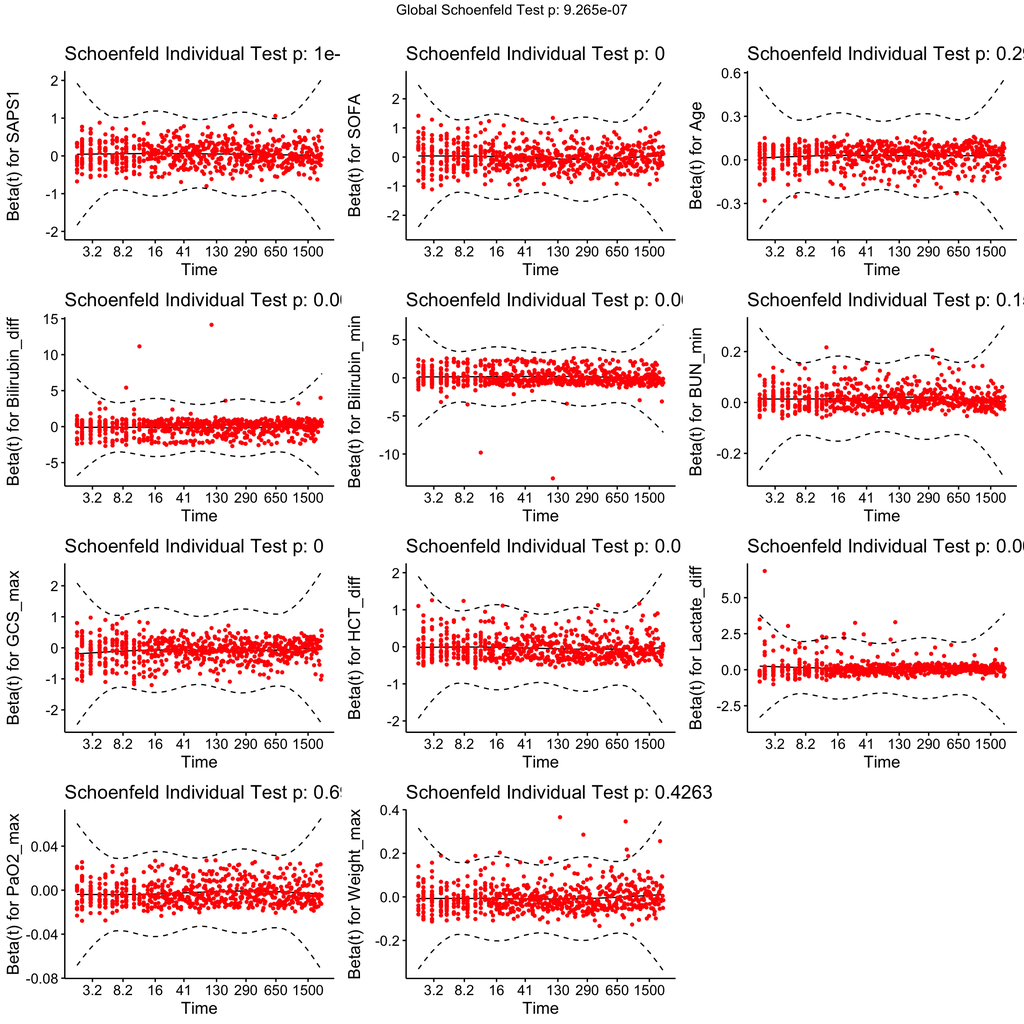

```r
ggcoxzph(prop.mvsig)
```

*Although we have chosen model 11 as the final model, we have added the ‘SOFA’ variable to the final model. Because although it was not found to be significant, it is a well known metric to assess organ failure rate in ICU, which is affecting patient’s survival rate and mortality especially in ICU settings (https://jamanetwork.com/journals/jama/fullarticle/194262).*

*From these plots, it appears that the curves crossed and the PH assumption may be violated. Recall that the proportional hazard assumption is supported by a non-significant relationship between residuals and time, while a significant relationship favours the alternative of non-constant hazards. The output from the proportional hazards test shows that the test is statistically significant for (p-value =1e-04) SAPS1, (p-value =0) SOFA, (p-value = 0.0052)Bilirubin_diff, (p-value = 0.0027)Bilirubin_min, (p-value = 0)GCS_max, (p-value = 0.0127)HCT_diff, (p-value = 0.0021)Lactate_diff. The global test is also statistically significant (p-value = 9.3e-07). Therefore, there appears to be a violation of the proportional hazards model.*

```r
cox.mvfinal <- coxph(Surv(Days, Status) ~ SAPS1 + SOFA + Age + BUN_min + GCS_max + HCT_diff + Weight_max, data = icu_final)
summary(cox.mvfinal)
```

```
## Call:
## coxph(formula = Surv(Days, Status) ~ SAPS1 + SOFA + Age + BUN_min +
##     GCS_max + HCT_diff + Weight_max, data = icu_final)
##
##   n= 873, number of events= 326
##
##                 coef exp(coef)  se(coef)      z Pr(>|z|)
## SAPS1       0.027737  1.028126  0.016230  1.709   0.0875 .
## SOFA       -0.026837  0.973520  0.021699 -1.237   0.2162
## Age         0.025321  1.025644  0.004642  5.454 4.92e-08 ***
## BUN_min     0.022003  1.022247  0.002144 10.264  < 2e-16 ***
## GCS_max    -0.121024  0.886013  0.018450 -6.559 5.40e-11 ***
## HCT_diff   -0.033558  0.966998  0.017594 -1.907   0.0565 .
## Weight_max -0.004759  0.995252  0.002808 -1.695   0.0901 .
## ---
## Signif. codes:  0 '***' 0.001 '**' 0.01 '*' 0.05 '.' 0.1 ' ' 1
##
##            exp(coef) exp(-coef) lower .95 upper .95
## SAPS1         1.0281     0.9726    0.9959    1.0614
## SOFA          0.9735     1.0272    0.9330    1.0158
## Age           1.0256     0.9750    1.0164    1.0350
## BUN_min       1.0222     0.9782    1.0180    1.0266
## GCS_max       0.8860     1.1287    0.8545    0.9186
## HCT_diff      0.9670     1.0341    0.9342    1.0009
## Weight_max    0.9953     1.0048    0.9898    1.0007
##
## Concordance= 0.714  (se = 0.014 )
## Likelihood ratio test= 191  on 7 df,   p=<2e-16
## Wald test            = 211.6  on 7 df,   p=<2e-16
## Score (logrank) test = 226.1  on 7 df,   p=<2e-16
```

*Final model does not include Bilirubin, Lactate, and PaO2 variables due to the remaining available variables after data cleaning of icu_patients_df0. From the output we can see that the final model fits to “icu_final” and only three variables ‘Age’, ‘BUN_min’ and ‘GCS_max’ are significant.*